# Problem Set 2

Due date: 25 September

Please upload your completed assignment to the ELMs course site (under the assignments menu). Remember to include an annotated script file for all work with R and show your math for all other problems (if applicable, or necessary). Please also upload your completed assignment to the Github repository that you have shared with us. *We should be able to run your script with no errors.*

**Total points: 30**

## Question 1

*Points: 5*

Using the `states` data, produce a scatterplot of the variables `womleg_2015` and `libpct_m` (with `womleg_2015` as the dependent variable on the y-axis). Describe the scatterplot and include a copy of it. Note any suspected outliers, if any (a visual inspection will suffice for this question). Lastly, give the general equation for the correlation between `womleg_2015` and `libpct_m` (include as much information as possible), but do not solve it.

**Note**

The `states` data set can be found in `poliscidata::states`. Take a look at `?states` to see what these variables measure.

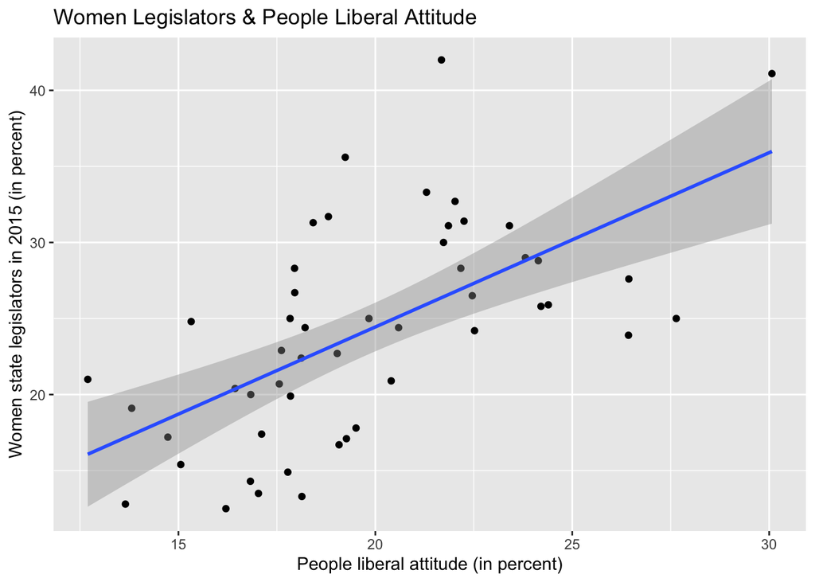

```
[1] 0.6088832
```

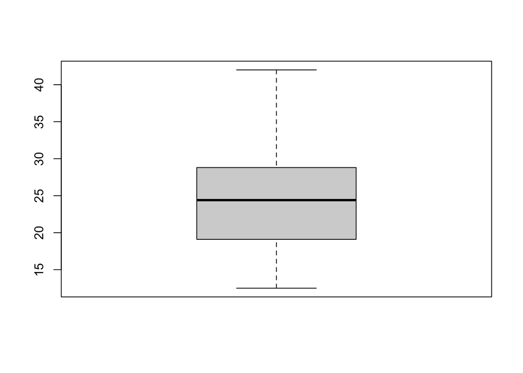

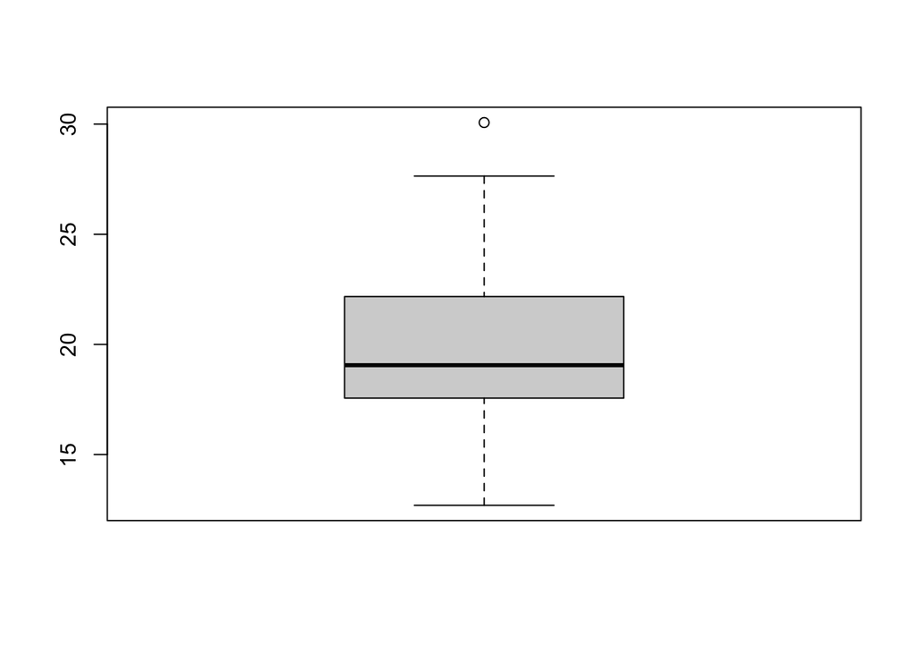

At least there is one suspected outlier in the libpct_m variable

Correlation equation:

$$r =\sum(x_i-x̄ /sx)(yi-ȳ/sy)/n-1$$

## **Question 2**

*Points: 5*

Regress `womleg_2015` (as the dependent variable) on `libpct_m` and report the results in a professionally formatted table. Write the model equation with the estimated coefficients and interpret them. What does the value of $R^2$ tell us about this model?

```
Call:
lm(formula = womleg_2015 ~ libpct_m, data = states)

Coefficients:
(Intercept)     libpct_m
      1.524        1.146
```

|  | (1) |
| --- | --- |
| (Intercept) | 1.524 |
| people liberal attitude | 1.146 |
| Num.Obs. | 50 |
| R2 | 0.371 |
| R2 Adj. | 0.358 |
| AIC | 318.4 |
| BIC | 324.1 |
| Log.Lik. | −156.205 |
| RMSE | 5.50 |

#Estimated coefficients:

womleg_2015<sub>x</sub>= 1.524 + 1.146*libpct_m<sub>x</sub> + *e*

Interpretation: For every one unit increase in people’s liberal attitude will affect the increase of women state legislature by 1.145 point. The value of R<sup>2</sup> means the amount of variation of my dependent variable can be explained by my independent variable, that is, around 37% of the number of women state legislature can be explained by how liberal people are.

## **Question 3**

*Points: 5*

Based on this regression, find the predicted value, the observed value, and compute the residual for the state of Colorado and then the state of Georgia. Lastly, compute the total aggregate error from those two select observations combined (i.e., Colorado and Georgia).

**Tip**

Think RSS.

```
# A tibble: 2 × 5
  term        estimate std.error statistic    p.value
  <chr>          <dbl>     <dbl>     <dbl>      <dbl>
1 (Intercept)     1.52     4.33      0.352 0.726
2 libpct_m        1.15     0.215     5.32  0.00000271
```

```
[1] 1.52399
```

```
[1] 1.145986
```

```
                                       state libpct_m  .fitted      diff
1 Colorado                                   21.67878 26.36757 -4.688783
2 Georgia                                    17.61538 21.71097 -4.095585
```

```
# A tibble: 1 × 1
  `sum(.resid^2)`
            <dbl>
1           1514.
```

```
[1] 38.7585
```

## Question 4

*Points: 5*

Using the `states` dataset, assess the relationship between the following two variables: `obama_win12` and `gun_rank3`. Construct a cross-tab and describe the nature of the relationship (if any) in detail.

**Note**

The variable `Obama_win12` is a dichotomous indicator of whether Obama won the state in 2012 (Obama won; Obama lost). The variable `gun_rank3` represents the general (ordinal) extent of gun restrictions in each state (more restrictions; middle restrictions; less restrictions).

**Caution**

Please note that you would customarily want a greater number of observations within each cell before conducting such an analysis.

| obama_win12 |  | More restr | Mid | Less restr | All |
| --- | --- | --- | --- | --- | --- |
| No | N | 1 | 5 | 18 | 24 |
|  | % row | 4.2 | 20.8 | 75.0 | 100.0 |
| Yes | N | 14 | 9 | 3 | 26 |
|  | % row | 53.8 | 34.6 | 11.5 | 100.0 |
| All | N | 15 | 14 | 21 | 50 |
|  | % row | 30.0 | 28.0 | 42.0 | 100.0 |

From the table, we can observe a strong correlation between whether or not Obama won the state in the 2012 election. In states where Obama lost, the majority of people favored fewer restrictions on gun control policy (75%), followed by moderate restrictions (20.8%), and more restrictions (4.2%). However, when Obama won in any states, the attitude is reversed: more people in the winning states favored stricter restrictions (53.8%), followed by moderate restrictions (34.6%), and less restrictions (11.5%).

## Question 5

*Points: 5*

I hypothesize that religious identifiers in the mass public are less likely to support federal government support of scientific research. I use data from the General Social Survey to evaluate this hypothesis. In particular, I use a three-category indicator of religious attendance to measure religious identification (low attendance; moderate attendance; high attendance) and a three-category indicator of perceptions toward the federal government’s support for scientific research (federal government provides “too little” support; “about right”; federal government provides “too much” support). Complete the cross-tab below so that you may properly evaluate my hypothesis.

**Note**

Table entries are raw counts of observations within each cell.

| Religious Attendence | Too Little | About Right | Too Much | All |
| --- | --- | --- | --- | --- |
| Low | 342 (47.9%) | 356 (41.6% | 106 (42.7%) | 804 |
| Moderate | 190 (26.6%) | 213 (24.9%) | 51 (20.56%) | 454 |
| High | 182 (25.5%) | 287 (33.5%) | 91 (36.7%) | 560 |
| All | 714 | 856 | 248 | 1818 |

The table shows that religious identification does not necessarily correlate with support for federal funding of scientific research. Although the number of those who reported that they rarely attend religious services are more likely to claim that the public funding is too little (47.9%) compared those with moderate (26.6%) or frequent attendances (25.5%), the number of those who claim the public funding is too much remain highest among those with low attendances of religious services (42.7%) compared to individuals with frequent attendance (36.7%). The same pattern holds when we account for individuals who report the federal funding for research is “about right”, in which those with fewer attendance remain on the top.

## Question 6

*Points: 5*

Say I wish to explore the relationship between the relative advantage of Democrats (`dem_advantage`) in a state and abortion policy (`abort_rank3`). The `dem_advantage` variable is a continuous indicator where higher values represent a greater Democratic advantage among the mass public; `abort_rank3` is an ordinal indicator for the extent of abortion restrictions in each state (fewer restrictions; middle restrictions; more restrictions). To explore this relationship, complete the following:

### Part A

Create a new variable (i.e., `dem_adv`) based on the `dem_advantage` variable. Calculate the summary statistics of `dem_advantage` and assign the following values to our new variable: if `dem_advantage` is less than the first quartile, set `dem_adv` to `Low`; if the value for `dem_advantage` is greater than the first quartile and less than the third quartile, set the value to `Mid`; and if the value of `dem_advantage` is greater than the third quartile, set the value to `High`.

```
   25%
-4.875
```

```
   75%
10.925
```

```
   Min. 1st Qu.  Median    Mean 3rd Qu.    Max.
-36.700  -4.875   0.950   0.948  10.925  24.000
```

### Part B

Create a crosstab using R; include your results in a professionally formatted table.

| abort_rank3 |  | High | Low | Mid | All |
| --- | --- | --- | --- | --- | --- |
| More restr | N | 0 | 6 | 11 | 17 |
|  | % row | 0.0 | 35.3 | 64.7 | 100.0 |
| Mid | N | 4 | 5 | 8 | 17 |
|  | % row | 23.5 | 29.4 | 47.1 | 100.0 |
| Less restr | N | 9 | 2 | 5 | 16 |
|  | % row | 56.2 | 12.5 | 31.2 | 100.0 |
| All | N | 13 | 13 | 24 | 50 |
|  | % row | 26.0 | 26.0 | 48.0 | 100.0 |

### Part C

What relationship (if any) is there between the relative advantage of Democrats is a given state and the restrictiveness of Abortion policy?

The relationship is that having more Democrats in any states is associated with less restrictions on abortion policy (56%) compared to fewer Democrats (12.5%). This is also confirm when we found that none of the ‘blue states’ favored more restrictions on abortion policy (0%), although the medium Democrats advantage tend to favor more restrictions on this policy (64.7%). The support for a moderate policy on abortion is somewhat divided among Democratic states, with medium Democrats tending to favor this moderate policy the most (47.1%), followed by low Democrats (29.4%) and high Democrats (23.5%).

Taken as a whole, having more democrats means less restrictions on abortion policies, and having fewer democrats mean vice versa.